# Getting started

**TipHere you will learn**

The basics of ConScape: importing data, running basic analyses, and exporting resulting maps.

1. Set up ConScape
2. Data import and RasterStack
3. Definition of a movement mode
4. Computation of connected habitat and betweenness measures
5. Exporting results to disk

# Setup the environment

**Warning**

This notebook assumes a running installation of Julia. If you didn’t already install Julia go here.

# Step 1: Install ConScape

In the first time we use ConsCape, we need to install the library. This step can be ignored in the afterwards, unless the user wants to reinstall or update the ConScape library to a new version.

Within the Julia environment, installing ConScape is as simple as:

```julia
] add ConScape
```

`]` puts us in package mode where we can install, update and inspect our installed packages.

## Load libraries

We continue, and usually would start, by loading the required libraries. You may also need to install these, as above

[output not shown]

This step is similar to using the `library()` function in R or the `import` command in Python.

When setting up the environment, it is also useful to setup the path to the folders where the input data are located and where we want to write the results of our analysis. Here we set the `datadir` data folder to the folder where the internal ConScape example datasets are saved, after the library is installed.

# Step 2: Data import and grid creation

## Import data

We start by importing and checking the input data to be used in ConScape. The first ConScape function is a helper to read maps in ASCII format, the function `readasc()`:

[output not shown]

## Define a RasterStack input

ConScape accepts a `RasterStack` as input, which is a collection of named raster layers.

These can be the following:

- `steplikelihood` : likelihood of movement (required). This maybe calculated from `stepcost` using the `likelihoodfunction` passed to `Problem`.
- `stepcost` : cost of movement. This maybe calculated from  
  `steplikelihood` using the `costfunction` passed to `Problem`.
- `quality`: habitat quality (required, or the below alternatives)
- `sourcequality`: source habitat quality if it does not match `quality`.
- `targetquality`: target habitat quality if it does not match `quality`.

```
┌ 117×87 RasterStack ┐
├────────────────────┴─────────────────────────────────────────────────── dims ┐
  ↓ X Projected{Float64} 110650.0:1000.0:226650.0 ForwardOrdered Regular Intervals{Start},
  → Y Projected{Float64} 6.98175e6:-1000.0:6.89575e6 ReverseOrdered Regular Intervals{Start}
├────────────────────────────────────────────────────────────────────── layers ┤
  :steplikelihood eltype: Float64 dims: X, Y size: 117×87
  :quality        eltype: Float64 dims: X, Y size: 117×87
├────────────────────────────────────────────────────────────────────── raster ┤
  missingval: NaN
  extent: Extent(X = (110650.0, 227650.0), Y = (6.89575e6, 6.98275e6))
  crs:
└──────────────────────────────────────────────────────────────────────────────┘
```

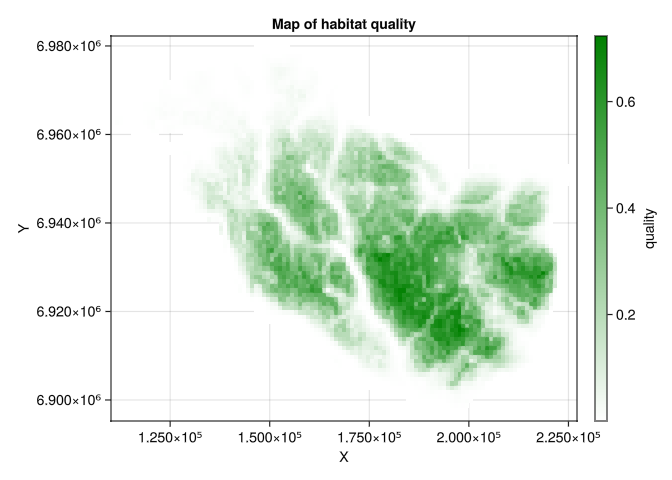

**Warning**

It is important that all cells or pixels that can be reached in the network (i.e. those with values for the permeability maps) also have matching habitat quality. Otherwise, the ‘NaN’ values may propagate in computations further down. This code ensures this match - simpliy masking the raster stack with itself.

```
┌ 117×87 RasterStack ┐
├────────────────────┴─────────────────────────────────────────────────── dims ┐
  ↓ X Projected{Float64} 110650.0:1000.0:226650.0 ForwardOrdered Regular Intervals{Start},
  → Y Projected{Float64} 6.98175e6:-1000.0:6.89575e6 ReverseOrdered Regular Intervals{Start}
├────────────────────────────────────────────────────────────────────── layers ┤
  :steplikelihood eltype: Float64 dims: X, Y size: 117×87
  :quality        eltype: Float64 dims: X, Y size: 117×87
├────────────────────────────────────────────────────────────────────── raster ┤
  missingval: NaN
  extent: Extent(X = (110650.0, 227650.0), Y = (6.89575e6, 6.98275e6))
  crs:
└──────────────────────────────────────────────────────────────────────────────┘
```